# 會員個體消費分析與RFM會員分群

#### 內容概述：以CDNOW_master 1997年1月1日至1998年6月30日的會員消費資料，做2個Part的分析

##### Part 1. 會員個體消費分析：

##### (1)會員消費時間遠近分布

##### (2)會員消費頻率分布

##### (3)會員消費金額分布

##### Part 2. RFM會員分群：

##### (1)將會員依據Recency、Frequency、Monetary數值進行1~4分的分級

##### (2)依據分級找出VIP、即將流失、沉睡、忠誠4類客戶

##### (3)將R、F、M分數加總，劃分會員為7等級

##### (4)了解7個等級會員在總會員數的佔比

```python
import pandas as pd
import numpy as np
import matplotlib.pyplot as plt
%matplotlib inline

columns = ['user_id', 'order_dt' , 'order_products', 'order_amount']
df=pd.read_table('CDNOW_master.txt', names = columns, sep='\s+')
df.head()
```

|  | user_id | order_dt | order_products | order_amount |
| --- | --- | --- | --- | --- |
| 0 | 1 | 19970101 | 1 | 11.77 |
| 1 | 2 | 19970112 | 1 | 12.00 |
| 2 | 2 | 19970112 | 5 | 77.00 |
| 3 | 3 | 19970102 | 2 | 20.76 |
| 4 | 3 | 19970330 | 2 | 20.76 |

```python
df.info()
#查看DataFrame摘要，總共69659列、4欄，無缺失值
```

```
<class 'pandas.core.frame.DataFrame'>
RangeIndex: 69659 entries, 0 to 69658
Data columns (total 4 columns):
 #   Column          Non-Null Count  Dtype
---  ------          --------------  -----
 0   user_id         69659 non-null  int64
 1   order_dt        69659 non-null  int64
 2   order_products  69659 non-null  int64
 3   order_amount    69659 non-null  float64
dtypes: float64(1), int64(3)
memory usage: 2.1 MB
```

```python
df.describe()
#使用.describe()查看基本的統計訊息
#可發現消費產品數平均值為2.4個商品，但是最大值達99，而訂單金額同樣可見平均數為35，最大值達1286，其中有極值存在
```

|  | user_id | order_dt | order_products | order_amount |
| --- | --- | --- | --- | --- |
| count | 69659.000000 | 6.965900e+04 | 69659.000000 | 69659.000000 |
| mean | 11470.854592 | 1.997228e+07 | 2.410040 | 35.893648 |
| std | 6819.904848 | 3.837735e+03 | 2.333924 | 36.281942 |
| min | 1.000000 | 1.997010e+07 | 1.000000 | 0.000000 |
| 25% | 5506.000000 | 1.997022e+07 | 1.000000 | 14.490000 |
| 50% | 11410.000000 | 1.997042e+07 | 2.000000 | 25.980000 |
| 75% | 17273.000000 | 1.997111e+07 | 3.000000 | 43.700000 |
| max | 23570.000000 | 1.998063e+07 | 99.000000 | 1286.010000 |

```python
df['order_dt']=pd.to_datetime(df.order_dt,format="%Y%m%d")
#轉換日期格式，設定為年月日
```

```python
rfm = df.pivot_table(index='user_id',
                     values=['order_products','order_amount','order_dt'],
                     aggfunc= {'order_dt':'max',
                               'order_amount':'sum',
                               'order_products':'sum'
                              })
rfm.head()
#以會員id為index製作資料透視表，並加入產品數(order_products)、金額（order_amount）、日期（order_dt）為值
```

| user_id | order_amount | order_dt | order_products |
| --- | --- | --- | --- |
| 1 | 11.77 | 1997-01-01 | 1 |
| 2 | 89.00 | 1997-01-12 | 6 |
| 3 | 156.46 | 1998-05-28 | 16 |
| 4 | 100.50 | 1997-12-12 | 7 |
| 5 | 385.61 | 1998-01-03 | 29 |

```python
rfm['Recency']= -(rfm.order_dt - rfm.order_dt.max()) / np.timedelta64(1,'D')
rfm['Recency']=rfm['Recency'].astype(int)
#將order_dt換算成最近一次消費日期（與所有日期的最大值相比），即可算出Recency值
```

```python
rfm.rename(columns={'order_products':'Frequency','order_amount':'MonetaryValue'},inplace=True)
#將'order_products'改命名為'Frequency'；'order_amount'改命名為'MonetaryValue'
rfm=rfm.drop('order_dt',axis=1)
rfm
```

| user_id | MonetaryValue | Frequency | Recency |
| --- | --- | --- | --- |
| 1 | 11.77 | 1 | 545 |
| 2 | 89.00 | 6 | 534 |
| 3 | 156.46 | 16 | 33 |
| 4 | 100.50 | 7 | 200 |
| 5 | 385.61 | 29 | 178 |
| ... | ... | ... | ... |
| 23566 | 36.00 | 2 | 462 |
| 23567 | 20.97 | 1 | 462 |
| 23568 | 121.70 | 6 | 434 |
| 23569 | 25.74 | 2 | 462 |
| 23570 | 94.08 | 5 | 461 |

23570 rows × 3 columns

```python
rfm_reset=rfm.reset_index()
rfm_reset
#將資料透視表解除
```

|  | user_id | MonetaryValue | Frequency | Recency |
| --- | --- | --- | --- | --- |
| 0 | 1 | 11.77 | 1 | 545 |
| 1 | 2 | 89.00 | 6 | 534 |
| 2 | 3 | 156.46 | 16 | 33 |
| 3 | 4 | 100.50 | 7 | 200 |
| 4 | 5 | 385.61 | 29 | 178 |
| ... | ... | ... | ... | ... |
| 23565 | 23566 | 36.00 | 2 | 462 |
| 23566 | 23567 | 20.97 | 1 | 462 |
| 23567 | 23568 | 121.70 | 6 | 434 |
| 23568 | 23569 | 25.74 | 2 | 462 |
| 23569 | 23570 | 94.08 | 5 | 461 |

23570 rows × 4 columns

## Part 1.會員個體消費分析

（1）繪製Recency的長條圖，可發現多數消費者最近一次消費日期為460天以前（約1年又3個月前）

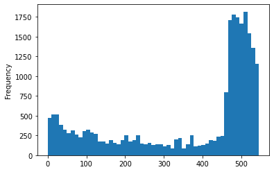

```python
rfm_reset.Recency.plot.hist(bins=55)
```

畫出MonetaryValue和Frequency的散佈圖，多數會員消費次數集中在200次以下，消費金額則集中在2000次以下

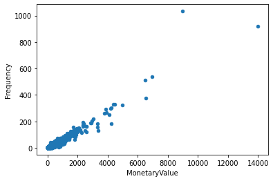

```python
rfm_reset.plot.scatter(x='MonetaryValue', y='Frequency')
```

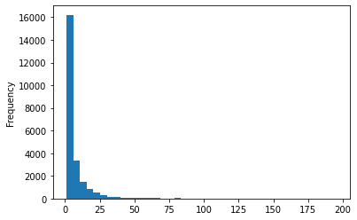

```python
rfm_reset.query('Frequency < 200').Frequency.plot.hist(bins=40)
```

（3）繪製Monetary<2000之會員分布的長條圖，可發現多數會員消費金額在500元以下，且集中在50元以下

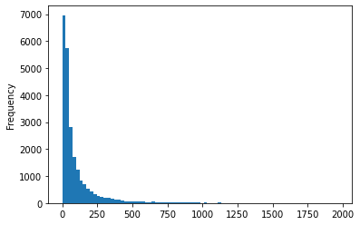

```python
rfm_reset.query('MonetaryValue < 2000').MonetaryValue.plot.hist(bins=80)
```

## Part.2 RFM會員分群

（1）首先依據四分位數將Rececy、Frequency、MonetaryValue劃分1-4分共4的等級

```python
r_labels=range(4,0,-1)
r_quartiles=pd.qcut(rfm_reset['Recency'],4,labels=r_labels)
rfm_reset=rfm_reset.assign(R=r_quartiles.values)
rfm_reset.head(10)
#依據四分位數將Recency設立分數標籤，由小到大排序，分為1~4分
```

|  | user_id | MonetaryValue | Frequency | Recency | R |
| --- | --- | --- | --- | --- | --- |
| 0 | 1 | 11.77 | 1 | 545 | 1 |
| 1 | 2 | 89.00 | 6 | 534 | 1 |
| 2 | 3 | 156.46 | 16 | 33 | 4 |
| 3 | 4 | 100.50 | 7 | 200 | 4 |
| 4 | 5 | 385.61 | 29 | 178 | 4 |
| 5 | 6 | 20.99 | 1 | 545 | 1 |
| 6 | 7 | 264.67 | 18 | 100 | 4 |
| 7 | 8 | 197.66 | 18 | 93 | 4 |
| 8 | 9 | 95.85 | 6 | 22 | 4 |
| 9 | 10 | 39.31 | 3 | 525 | 1 |

```python
m_labels=range(1,5)
m_quartiles=pd.qcut(rfm_reset['MonetaryValue'],4,labels=m_labels)
rfm_reset=rfm_reset.assign(M=m_quartiles.values)
rfm_reset.head(10)
#依據四分位數將MonetaryValue設立分數標籤，由大到小排序，分為1~4分
```

|  | user_id | MonetaryValue | Frequency | Recency | R | M |
| --- | --- | --- | --- | --- | --- | --- |
| 0 | 1 | 11.77 | 1 | 545 | 1 | 1 |
| 1 | 2 | 89.00 | 6 | 534 | 1 | 3 |
| 2 | 3 | 156.46 | 16 | 33 | 4 | 4 |
| 3 | 4 | 100.50 | 7 | 200 | 4 | 3 |
| 4 | 5 | 385.61 | 29 | 178 | 4 | 4 |
| 5 | 6 | 20.99 | 1 | 545 | 1 | 2 |
| 6 | 7 | 264.67 | 18 | 100 | 4 | 4 |
| 7 | 8 | 197.66 | 18 | 93 | 4 | 4 |
| 8 | 9 | 95.85 | 6 | 22 | 4 | 3 |
| 9 | 10 | 39.31 | 3 | 525 | 1 | 2 |

依據四分位數將Frequency設立分數標籤，發現無法分為4等份，故改用自定義方式切割

```python
rfm_reset.Frequency.describe()
#首先找出Frequency的四分位數，分別為1,3,7，極大值為1033，保留這些數字1,3,7,1034作為bins數值
```

```
count    23570.000000
mean         7.122656
std         16.983531
min          1.000000
25%          1.000000
50%          3.000000
75%          7.000000
max       1033.000000
Name: Frequency, dtype: float64
```

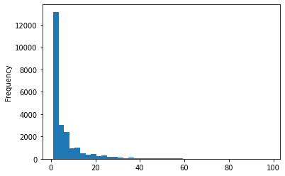

```python
rfm_reset.query('Frequency < 100').Frequency.plot.hist(bins=40)
#縮減Frequency至100次以下，發現20次後明顯次數上升較多，故將20列為bins值之一
```

```python
rfm_reset['F']=pd.cut(rfm_reset['Frequency'],bins=[1, 3, 7, 20, 1034],labels=[1,2,3,4], right=False).astype(int)
rfm_reset
#以1~3、3~7、7~20、20~1034將Frequency分組，由大到小以1~4評分
```

|  | user_id | MonetaryValue | Frequency | Recency | R | M | F |
| --- | --- | --- | --- | --- | --- | --- | --- |
| 0 | 1 | 11.77 | 1 | 545 | 1 | 1 | 1 |
| 1 | 2 | 89.00 | 6 | 534 | 1 | 3 | 2 |
| 2 | 3 | 156.46 | 16 | 33 | 4 | 4 | 3 |
| 3 | 4 | 100.50 | 7 | 200 | 4 | 3 | 3 |
| 4 | 5 | 385.61 | 29 | 178 | 4 | 4 | 4 |
| ... | ... | ... | ... | ... | ... | ... | ... |
| 23565 | 23566 | 36.00 | 2 | 462 | 3 | 2 | 1 |
| 23566 | 23567 | 20.97 | 1 | 462 | 3 | 2 | 1 |
| 23567 | 23568 | 121.70 | 6 | 434 | 3 | 4 | 2 |
| 23568 | 23569 | 25.74 | 2 | 462 | 3 | 2 | 1 |
| 23569 | 23570 | 94.08 | 5 | 461 | 3 | 3 | 2 |

23570 rows × 7 columns

```python
rfm_reset['R']=rfm_reset['R'].astype(int)
rfm_reset['F']=rfm_reset['F'].astype(int)
rfm_reset['M']=rfm_reset['M'].astype(int)
#將R,F,M轉換為int格式
```

```python
def join_rfm_reset(x): return str(x['R']) + str(x['F']) + str(x['M'])
rfm_reset['RFM_Segment']=rfm_reset.apply(join_rfm_reset,axis=1)
rfm_reset['RFM_Score']=rfm_reset[['R','F','M']].sum(axis=1)
rfm_reset
#接下來將RFM分數加總
```

|  | user_id | MonetaryValue | Frequency | Recency | R | M | F | RFM_Segment | RFM_Score |
| --- | --- | --- | --- | --- | --- | --- | --- | --- | --- |
| 0 | 1 | 11.77 | 1 | 545 | 1 | 1 | 1 | 111 | 3 |
| 1 | 2 | 89.00 | 6 | 534 | 1 | 3 | 2 | 123 | 6 |
| 2 | 3 | 156.46 | 16 | 33 | 4 | 4 | 3 | 434 | 11 |
| 3 | 4 | 100.50 | 7 | 200 | 4 | 3 | 3 | 433 | 10 |
| 4 | 5 | 385.61 | 29 | 178 | 4 | 4 | 4 | 444 | 12 |
| ... | ... | ... | ... | ... | ... | ... | ... | ... | ... |
| 23565 | 23566 | 36.00 | 2 | 462 | 3 | 2 | 1 | 312 | 6 |
| 23566 | 23567 | 20.97 | 1 | 462 | 3 | 2 | 1 | 312 | 6 |
| 23567 | 23568 | 121.70 | 6 | 434 | 3 | 4 | 2 | 324 | 9 |
| 23568 | 23569 | 25.74 | 2 | 462 | 3 | 2 | 1 | 312 | 6 |
| 23569 | 23570 | 94.08 | 5 | 461 | 3 | 3 | 2 | 323 | 8 |

23570 rows × 9 columns

```python
rfm_reset.groupby('RFM_Segment').agg({
    'Recency':'mean',
    'Frequency':'mean',
    'MonetaryValue':['mean','count']}).round(1)
#了解RFM_Segment分群的數量狀況，可發現總共有45類，透過這些分類我們可以初步了解幾個重要的客群
```

| RFM_Segment | Recency mean | Frequency mean | MonetaryValue mean | MonetaryValue count |
| --- | --- | --- | --- | --- |
| 111 | 523.7 | 1.0 | 13.4 | 2606 |
| 112 | 523.7 | 1.7 | 28.3 | 1606 |
| 113 | 524.1 | 1.6 | 58.1 | 187 |
| 114 | 530.1 | 1.4 | 173.0 | 15 |
| 121 | 519.4 | 3.2 | 17.4 | 9 |
| 122 | 522.8 | 3.1 | 37.3 | 373 |
| 123 | 523.3 | 4.1 | 62.9 | 826 |
| 124 | 522.2 | 5.0 | 134.8 | 36 |
| 132 | 523.0 | 7.0 | 40.5 | 1 |
| 133 | 521.6 | 7.6 | 89.5 | 60 |
| 134 | 522.2 | 10.3 | 159.5 | 140 |
| 144 | 519.4 | 25.8 | 373.9 | 16 |
| 211 | 488.2 | 1.0 | 13.4 | 2513 |
| 212 | 488.6 | 1.7 | 28.4 | 1561 |
| 213 | 488.4 | 1.6 | 56.3 | 160 |
| 214 | 487.4 | 1.5 | 153.8 | 12 |
| 221 | 482.0 | 3.2 | 17.9 | 5 |
| 222 | 488.1 | 3.1 | 37.4 | 419 |
| 223 | 487.9 | 4.2 | 63.3 | 889 |
| 224 | 488.7 | 5.1 | 145.7 | 40 |
| 233 | 488.6 | 7.5 | 91.9 | 82 |
| 234 | 487.5 | 10.3 | 159.2 | 199 |
| 244 | 490.3 | 30.7 | 525.3 | 19 |
| 311 | 460.2 | 1.1 | 13.5 | 752 |
| 312 | 406.1 | 1.9 | 28.8 | 949 |
| 313 | 399.4 | 1.9 | 56.1 | 104 |
| 314 | 402.7 | 1.9 | 149.5 | 9 |
| 321 | 387.2 | 3.0 | 17.0 | 4 |
| 322 | 372.1 | 3.1 | 37.6 | 502 |
| 323 | 367.7 | 4.5 | 65.9 | 1703 |
| 324 | 341.0 | 5.2 | 137.3 | 118 |
| 333 | 342.2 | 7.4 | 92.8 | 299 |
| 334 | 328.5 | 11.4 | 171.2 | 1155 |
| 344 | 312.2 | 31.7 | 472.1 | 304 |
| 411 | 117.9 | 2.0 | 16.4 | 14 |
| 412 | 108.3 | 2.0 | 28.6 | 231 |
| 413 | 114.4 | 2.0 | 57.9 | 22 |
| 414 | 95.0 | 2.0 | 134.0 | 1 |
| 421 | 96.3 | 3.0 | 17.9 | 3 |
| 422 | 110.0 | 3.2 | 37.2 | 237 |
| 423 | 99.8 | 4.7 | 68.2 | 1190 |
| 424 | 98.5 | 5.3 | 140.2 | 89 |
| 433 | 91.8 | 7.5 | 94.5 | 370 |
| 434 | 83.4 | 12.4 | 185.3 | 2226 |
| 444 | 58.8 | 43.4 | 638.6 | 1514 |

（2-1）了解支付金額最高前5名VIP客戶（找出RFM_Segment = 444的客戶，並按金額由大到小排序）

```python
rfm_reset[rfm_reset['RFM_Segment']=='444'].sort_values('MonetaryValue', ascending=False).head()
```

|  | user_id | MonetaryValue | Frequency | Recency | R | M | F | RFM_Segment | RFM_Score |
| --- | --- | --- | --- | --- | --- | --- | --- | --- | --- |
| 7591 | 7592 | 13990.93 | 917 | 1 | 4 | 4 | 4 | 444 | 12 |
| 14047 | 14048 | 8976.33 | 1033 | 0 | 4 | 4 | 4 | 444 | 12 |
| 7982 | 7983 | 6973.07 | 536 | 5 | 4 | 4 | 4 | 444 | 12 |
| 7930 | 7931 | 6497.18 | 514 | 17 | 4 | 4 | 4 | 444 | 12 |
| 6568 | 6569 | 4968.00 | 322 | 7 | 4 | 4 | 4 | 444 | 12 |

```python
rfm_reset[rfm_reset['R'] <= 2 ].sort_values('MonetaryValue', ascending=False).head(5)
```

|  | user_id | MonetaryValue | Frequency | Recency | R | M | F | RFM_Segment | RFM_Score |
| --- | --- | --- | --- | --- | --- | --- | --- | --- | --- |
| 12303 | 12304 | 1134.15 | 35 | 489 | 2 | 4 | 4 | 244 | 10 |
| 18846 | 18847 | 1119.68 | 32 | 480 | 2 | 4 | 4 | 244 | 10 |
| 2760 | 2761 | 990.28 | 35 | 498 | 2 | 4 | 4 | 244 | 10 |
| 8528 | 8529 | 846.23 | 62 | 487 | 2 | 4 | 4 | 244 | 10 |
| 2929 | 2930 | 772.42 | 60 | 480 | 2 | 4 | 4 | 244 | 10 |

（2-3）了解消費時間距遠最近的前5名沉睡客戶（找出RFM_Segment = 111的客戶，並按Recency由大到小排序）

```python
rfm_reset[rfm_reset['RFM_Segment']=='111'].sort_values('Recency',ascending=False).head(5)
```

|  | user_id | MonetaryValue | Frequency | Recency | R | M | F | RFM_Segment | RFM_Score |
| --- | --- | --- | --- | --- | --- | --- | --- | --- | --- |
| 0 | 1 | 11.77 | 1 | 545 | 1 | 1 | 1 | 111 | 3 |
| 189 | 190 | 15.36 | 1 | 545 | 1 | 1 | 1 | 111 | 3 |
| 158 | 159 | 19.75 | 2 | 545 | 1 | 1 | 1 | 111 | 3 |
| 159 | 160 | 19.74 | 2 | 545 | 1 | 1 | 1 | 111 | 3 |
| 167 | 168 | 14.96 | 1 | 545 | 1 | 1 | 1 | 111 | 3 |

（2-4）了解消費金額高的前5名忠誠客戶（找出F值>=3的客戶，並按金額由大到小排序）

```python
rfm_reset[rfm_reset['F'] >= 3 ].sort_values('MonetaryValue', ascending=False).head(5)
```

|  | user_id | MonetaryValue | Frequency | Recency | R | M | F | RFM_Segment | RFM_Score |
| --- | --- | --- | --- | --- | --- | --- | --- | --- | --- |
| 7591 | 7592 | 13990.93 | 917 | 1 | 4 | 4 | 4 | 444 | 12 |
| 14047 | 14048 | 8976.33 | 1033 | 0 | 4 | 4 | 4 | 444 | 12 |
| 7982 | 7983 | 6973.07 | 536 | 5 | 4 | 4 | 4 | 444 | 12 |
| 19338 | 19339 | 6552.70 | 378 | 445 | 3 | 4 | 4 | 344 | 11 |
| 7930 | 7931 | 6497.18 | 514 | 17 | 4 | 4 | 4 | 444 | 12 |

```python
rfm_reset.groupby('RFM_Score').agg({
    'Recency':'mean',
    'Frequency':'mean',
    'MonetaryValue':['mean','count']}).round(1)
#了解每種RFM_Score的總覽，可發現總共有10類（3~12分）
```

| RFM_Score | Recency mean | Frequency mean | MonetaryValue mean | MonetaryValue count |
| --- | --- | --- | --- | --- |
| 3 | 523.7 | 1.0 | 13.4 | 2606 |
| 4 | 502.1 | 1.3 | 19.2 | 4128 |
| 5 | 487.9 | 1.7 | 27.5 | 2878 |
| 6 | 465.6 | 2.9 | 44.8 | 2388 |
| 7 | 404.7 | 3.6 | 54.3 | 1837 |
| 8 | 354.3 | 4.8 | 71.4 | 2233 |
| 9 | 201.1 | 6.0 | 89.4 | 1823 |
| 10 | 264.2 | 10.4 | 156.3 | 1633 |
| 11 | 110.8 | 14.7 | 219.8 | 2530 |
| 12 | 58.8 | 43.4 | 638.6 | 1514 |

（3）定義客戶分群，將客戶分為7個類別

```python
def segment_me(df):
    if df['RFM_Score']>=9:
        return'1.Can\'t Loose Them'
    elif (df['RFM_Score']>=8) and (df['RFM_Score'] <9):
        return'2.Champions'
    elif (df['RFM_Score']>=7) and (df['RFM_Score'] <8):
        return'3.Loyal'
    elif (df['RFM_Score']>=6) and (df['RFM_Score'] <7):
        return'4.Potential'
    elif (df['RFM_Score']>=5) and (df['RFM_Score'] <6):
        return'5.Promising'
    elif (df['RFM_Score']>=4) and (df['RFM_Score'] <5):
        return'6.Needs Attention'
    else:
        return'7.Require Activation'
rfm_reset['General_Segment']=rfm_reset.apply(segment_me,axis=1)
```

（4）分群後將客戶依照重要性排序，發現第一等級的重要客群人數最多，且消費頻次平均在17次以上、消費金額平均超過258

```python
rfm_reset.groupby('General_Segment').agg({
    'Recency':'mean',
    'Frequency':'mean',
    'MonetaryValue':['mean','count']}).round(1)
```

| General_Segment | Recency mean | Frequency mean | MonetaryValue mean | MonetaryValue count |
| --- | --- | --- | --- | --- |
| 1.Can't Loose Them | 155.7 | 17.4 | 258.8 | 7500 |
| 2.Champions | 354.3 | 4.8 | 71.4 | 2233 |
| 3.Loyal | 404.7 | 3.6 | 54.3 | 1837 |
| 4.Potential | 465.6 | 2.9 | 44.8 | 2388 |
| 5.Promising | 487.9 | 1.7 | 27.5 | 2878 |
| 6.Needs Attention | 502.1 | 1.3 | 19.2 | 4128 |
| 7.Require Activation | 523.7 | 1.0 | 13.4 | 2606 |

（8）畫出各分類客戶人數分布占比，可發現大多數客戶為不可流失的重要客戶（32%），而有11%的客戶為已流失客戶

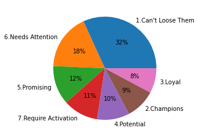

```python
plt.pie(rfm_reset.General_Segment.value_counts(),
        labels=rfm_reset.General_Segment.value_counts().index,
        autopct='%.0f%%')
plt.show()
```

```python
#匯出csv
rfm_reset.to_csv("CDNOW_0302_datacamp_ver.csv", encoding="utf_8_sig")
```